# Fractals

None

## 10 Fractals

Modified from [Mandelbrot Set](https://primer-computational-mathematics.github.io/book/c_mathematics/complex_analysis/6_fractals.html#mandelbrot-set)

**Fractals** are never-ending, very complex patterns that are self-similar at different scales. They are created through recursion. The name fractal has been coined in 1970s by Benoit Mandelbrot (1924 - 2010), the father of fractals. In 1982, in the book titled "The Fractal Geometry of Nature", Mandelbrot argued that most objects in nature are irregular and complicated. We do find fractal-like patterns in nature, e.g. frost crystals on the glass. However, they are not true fractals because their scaling is finite. The figure below shows a snapshot from a river network, seen from the sky. Zooming in or out would not return exactly the same pattern, but something similar.

[figure not shown]

```python
import numpy as np
import matplotlib.pyplot as plt
```

The Mandelbrot set, $M$, is constructed with a set of complex numbers $c$ for which the polynomial, $P(z)=z^2+c$, does not diverge when iterated from $z=0$ through $P(P(0))$, $P(P(P(0)))$ and so on. We can construct it ourselves. Let's define *mandelbrot* function first that takes inputs $z$ and complex number $c$.

```python
def mandelbrot(z,c):
    return z**2+c
```

Let's make a first check:

```python
z = 0j
for k in range(10):
    z = mandelbrot(z,1)
    print (z)
```

```
(1+0j)
(2+0j)
(5+0j)
(26+0j)
(677+0j)
(458330+0j)
(210066388901+0j)
(4.4127887745906175e+22+0j)
(1.9472704769152963e+45+0j)
(3.7918623102659254e+90+0j)
```

Let's use this function over and over again and check the convergence. In the following code the 'mandelbrot' function is applied up to 50 times. 4 is the threshold that is chosen to indicate convergence.

```python
nmax = 50       # maximum number of Mandelbrot applications
threshold = 4   # threshold to indicate convergence
c = -1.1

z = 0j; m = 0
for k in range(nmax):
    z = mandelbrot(z, c)
    if abs(z) > threshold:
        m = 1
        break

if m==1:
    print ('divergent')
else:
    print ('no divergence')
```

```
no divergence
```

**Task 1**: Change the 'c', which is the second parameter in the 'mandelbrot' call, and check the results.

We specify vectors of $x$ and $y$ coordinates in real space, that will be used to construct a mesh, represented by the real-valued matrices X and Y. These are combined to a matrix a complex numbers $Z$, which represents in fact a mesh in the complex plane. The basic algorithm for creating Mandelbrot set iterates over each value of $Z$. For each element $c$ of $Z$, we iterate over $n_{max}$ and check whether the polynomial $z^{n+1}=z^n+c$ converges. Below we present code for $n_{max}=50$ and threshold $4$. We plot the $M$ array with the 'imshow' function to reveal the Mandelbrot set.

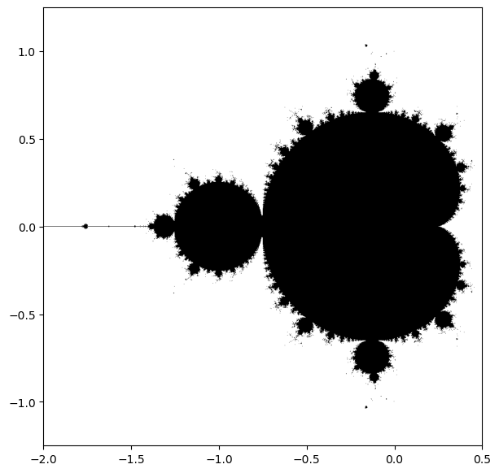

```python
n = 1001
x = np.linspace(-2.0,0.5,n); y = np.linspace(-1.25,1.25,n)
X,Y = np.meshgrid(x,y); Z = X + Y*1j

M = np.zeros((n,n))
nmax = 50

for i in range(len(M)):
    for j in range(len(M[i])):
        z=0j
        for k in range(nmax):
            z = mandelbrot(z, Z[i,j])
            if abs(z) > 4:
                M[i,j] = 1
                break

plt.figure(figsize=(7,7))
plt.imshow(M, cmap="binary_r", extent=[min(x), max(x), min(y), max(y)])
plt.show()
```

If we wanted to create a colour picture, instead of breaking the loop based on divergence threshold, we can assign values $m$ to each non-diverging point. This value will increase by 1, each time abs $(z) < $ threshold in the loop. If the final $m$ value is below the threshold, then we can set the value of Mandelbrot set to $m$.

[figure not shown]

```python
n = 1001
x = np.linspace(-2.0,0.5,n); y = np.linspace(-1.25,1.25,n)
X, Y = np.meshgrid(x,y); Z = X + Y*1j

M = np.zeros((n,n))
nmax = 100

for i in range(len(M)):
    for j in range(len(M[i])):
        z=0j
        m = 0
        for k in range(nmax):
            z = mandelbrot(z, Z[i,j])
            if abs(z) < 50:
                m = m+1
            else:
                break
        if m < 50:
            M[i,j] = m

plt.figure(figsize=(7,7))
plt.imshow(M, cmap="inferno")
plt.axis("off")
plt.show()
```

We can zoom into the calculated Mandelbrot set and see beautiful patterns.

[figure not shown]

```python
plt.figure(figsize=(7,7))
plt.imshow(M, cmap="inferno")

plt.xlim(600,900)
plt.ylim(700,900)
plt.axis("off")
plt.show()
```

We can create zoomed in versions of the Mandelbrot by choosing smaller ranges of $x$ and $y$ that create complex numbers $c$. You can play yourself with different ranges and different colourmaps! Below we show an example:

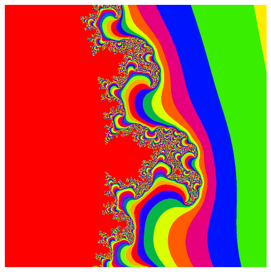

```python
n = 1001
x = np.linspace(0.3,0.5,n); y = np.linspace(0.1,0.3,n)
X, Y = np.meshgrid(x,y); Z = X + Y*1j

M = np.zeros((n,n))
nmax = 100

for i in range(len(M)):
    for j in range(len(M[i])):
        z=0j
        m = 0
        for k in range(nmax):
            z = mandelbrot(z, Z[i,j])
            if abs(z) < 50:
                m = m+1
            else:
                break
        if m < 50:
            M[i,j] = m

plt.figure(figsize=(7,7))
plt.imshow(M, cmap="prism")
plt.axis("off")
plt.show()
```

**Julia Sets** are based on the same iterative formula $P(z)$ as the Mandelbrot set. But instead of varying the increment $c$ the starting point is chosen as variable. The following code creates an example image. The treshold for measuring divergence is set to 2.

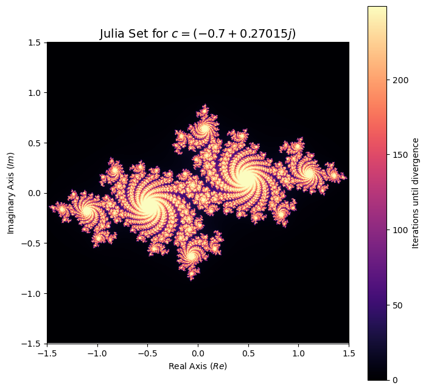

```python
def generate_julia_set(c, width=800, height=800, max_iter=250, x_lim=(-1.5, 1.5), y_lim=(-1.5, 1.5)):
    """
    Generates a Julia set fractal for a given complex number 'c'.
    """
    # Create a dense grid of complex numbers across the specified plane boundaries
    x = np.linspace(x_lim[0], x_lim[1], width)
    y = np.linspace(y_lim[0], y_lim[1], height)
    X, Y = np.meshgrid(x, y)
    Z = X + 1j * Y

    # Initialize an image array to track how many iterations it takes to diverge
    img = np.zeros(Z.shape, dtype=int)

    # Vectorized escape-time algorithm loop
    for i in range(max_iter):
        # Create a boolean mask where points have not yet escaped to infinity
        mask = np.abs(Z) <= 2.0
        Z[mask] = Z[mask]**2 + c
        img[mask] = i

    return img

# Define a specific complex parameter 'c' to shape the fractal
c_parameter = -0.7 + 0.27015j

# Generate the fractal matrix
julia_img = generate_julia_set(c=c_parameter)

# Plot the matrix using matplotlib
plt.figure(figsize=(8, 8))
plt.imshow(julia_img, cmap='magma', extent=[-1.5, 1.5, -1.5, 1.5])
plt.colorbar(label='Iterations until divergence')
plt.title(f'Julia Set for $c = {c_parameter}$', fontsize=14)
plt.xlabel('Real Axis ($Re$)')
plt.ylabel('Imaginary Axis ($Im$)')
plt.axis('on')
plt.show()
```

Here some famous examples:

- Dendrite Fractal: c = -0.4 + 0.6j
- Douady's Rabbit: c = -0.123 + 0.745j
- San Marco Fractal: c = -0.75 + 0.0j
- Siegel Disk Fractal: c = -0.391 - 0.587j

One may also change the exponent of the function or use a completely different formulation. For more examples see: [Julia Set Fractal (2D)](https://paulbourke.net/fractals/juliaset/)